# Assignment 11

Richard Fischer

December 5, 2019

```r
library(ggplot2)
require(data.table)
paydata <- as.data.frame(fread("State_Employee_Payroll_Data_Calendar_Year_2015_through_Present.tsv"))

paydata <- subset(paydata, paydata$`Full/Part` == "F")
attach(paydata)
paydata$fullName <- paste(`First Name`, `Middle Initial`, `Last Name`, sep = '')

df2 <- aggregate(`Bi-Weekly Comp Rate`, by = c(list(paydata$fullName),
                                              list(`Pyrl Fiscal Yr`)),
                                              median)
colnames(df2) <- c('Name', "Year", "Amount")

y2015 <- subset(df2, df2$Year == 2015)
y2015 <- cbind(y2015$Name, as.numeric(y2015$Amount))
colnames(y2015) <- c("Name", "2015")

y2016 <- subset(df2, df2$Year == 2016)
y2016 <- cbind(y2016$Name, as.numeric(y2016$Amount))
colnames(y2016) <- c("Name", "2016")

y2017 <- subset(df2, df2$Year == 2017)
y2017 <- cbind(y2017$Name, as.numeric(y2017$Amount))
colnames(y2017) <- c("Name", "2017")

y2018 <- subset(df2, df2$Year == 2018)
y2018 <- cbind(y2018$Name, as.numeric(y2018$Amount))
colnames(y2018) <- c("Name", "2018")

y2019 <- subset(df2, df2$Year == 2019)
y2019 <- cbind(y2019$Name, as.numeric(y2019$Amount))
colnames(y2019) <- c("Name", "2019")

y2020 <- subset(df2, df2$Year == 2020)
y2020 <- cbind(y2020$Name, as.numeric(y2020$Amount))
colnames(y2020) <- c("Name", "2020")


newdata <- merge(y2015, y2016, by.x = 'Name', by.y = 'Name', all.x = TRUE, all.y = TRUE)
newdata <- merge(newdata, y2017, by.x = 'Name', by.y = 'Name', all.x = TRUE, all.y = TRUE)
newdata <- merge(newdata, y2018, by.x = 'Name', by.y = 'Name', all.x = TRUE, all.y = TRUE)
newdata <- merge(newdata, y2019, by.x = 'Name', by.y = 'Name', all.x = TRUE, all.y = TRUE)
newdata <- merge(newdata, y2020, by.x = 'Name', by.y = 'Name', all.x = TRUE, all.y = TRUE)

newdata[newdata == 0] <- NA

newdata$`2015` <- as.numeric(newdata$`2015`)
newdata$`2016` <- as.numeric(newdata$`2016`)
newdata$`2017` <- as.numeric(newdata$`2017`)
newdata$`2018` <- as.numeric(newdata$`2018`)
newdata$`2019` <- as.numeric(newdata$`2019`)
newdata$`2020` <- as.numeric(newdata$`2020`)


newdata$raise2016 <- (newdata$`2016` - newdata$`2015`) / newdata$`2015`
newdata$raise2017 <- (newdata$`2017` - newdata$`2016`) / newdata$`2016`
newdata$raise2018 <- (newdata$`2018` - newdata$`2017`) / newdata$`2017`
newdata$raise2019 <- (newdata$`2019` - newdata$`2018`) / newdata$`2018`
newdata$raise2020 <- (newdata$`2020` - newdata$`2019`) / newdata$`2019`

head(newdata)
```

```
##                     Name  2015  2016  2017 2018 2019 2020  raise2016
## 1           A BATESLYONS    NA    NA 11098   NA   NA   NA         NA
## 2            A SusanPeck 10254 11064    NA   NA   NA   NA 0.07899356
## 3           A. BenOumlil  8844  9657  9824 9419 9177 9520 0.09192673
## 4 A. BethanyZorba Morris  8251  8827  8893 8525 8302 8539 0.06980972
## 5        A. BrianSchwarz  3171  3344  5738 5474 5294 5808 0.05455692
## 6    A. WilliamMottolese    NA    NA    NA   NA   NA   NA         NA
##     raise2017   raise2018   raise2019  raise2020
## 1          NA          NA          NA         NA
## 2          NA          NA          NA         NA
## 3 0.017293155 -0.04122557 -0.02569275 0.03737605
## 4 0.007477059 -0.04138086 -0.02615836 0.02854734
## 5 0.715909091 -0.04600906 -0.03288272 0.09709105
## 6          NA          NA          NA         NA
```

For this dataset, I had to do a lot of data wrangling. First, I subsetted the data to only include full time, regular employees. Then, I concatenated the first, middle, and last name together to get a set of full names, and found the median bi-weekly payment for each person for each fiscal year. After that, I transformed this into a matrix with each row representing each person and each column representing the median bi-weekly payment for a year. Finally, I found the percentage difference between each column and the column to the left of it to calculate the percentage raise that each person received each year.

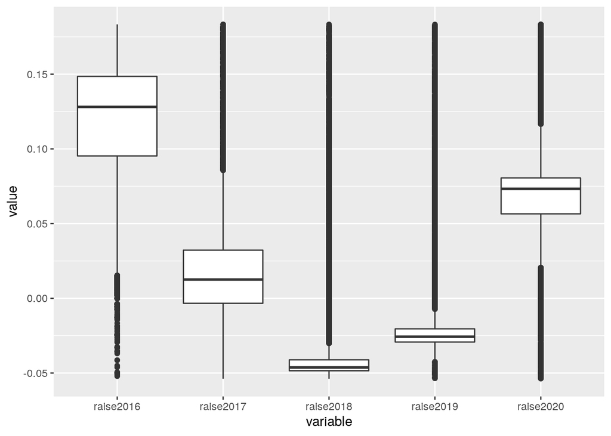

```r
newdata <- newdata[, c('Name', 'raise2016', 'raise2017', 'raise2018', 'raise2019', 'raise2020')]
newdata <- data.table(newdata)
raises <- melt.data.table(newdata,
                          id.vars = c("Name"),
                          measure.vars = c("raise2016", "raise2017", "raise2018", "raise2019", "raise2020"),
                          na.rm = TRUE)

ggplot(raises, aes(x=variable, y=value)) +
  geom_boxplot() +
  scale_y_continuous(limits = quantile(raises$value, c(0.1, 0.9)))
```

The first figure I made is a boxplot of all of the raises by year. We see that 2016 had a lot of raises, but then the raises decreased to an all time low in 2018. Then, they came back up by 2020.

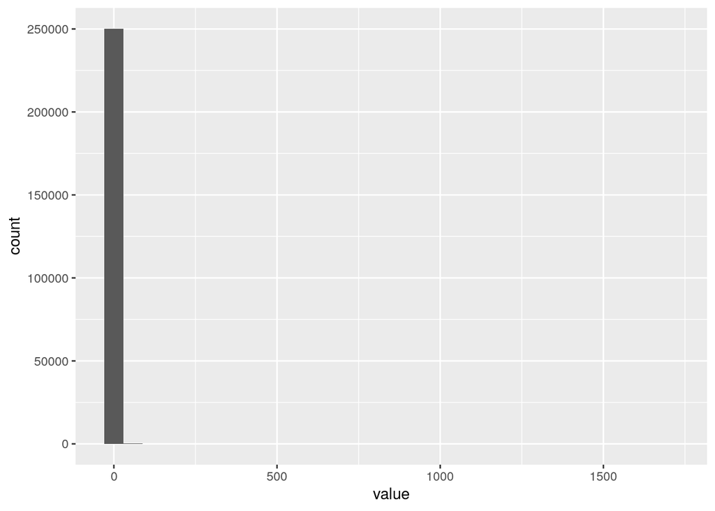

```r
ggplot(raises) +
  geom_histogram(aes(value))
```

Here I wanted to look at the distribution of the raises. Because of some outliers, our scale is very off, so I changed the x limit for the chart.

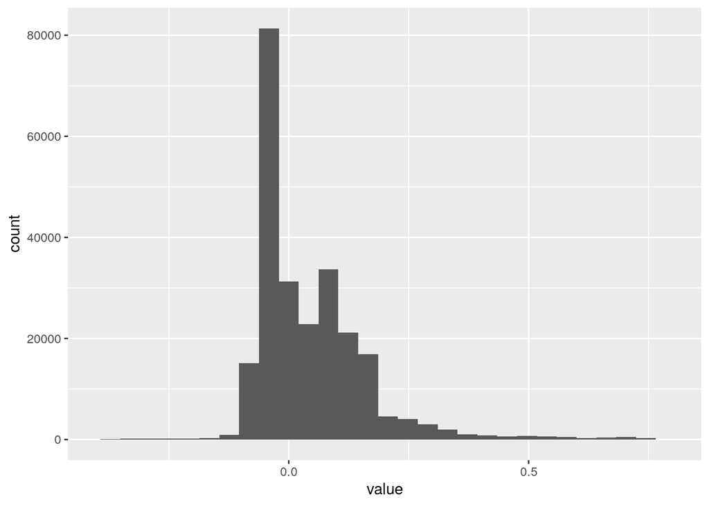

```r
ggplot(raises) +
  geom_histogram(aes(value)) +
  xlim(-0.4, 0.8)
```

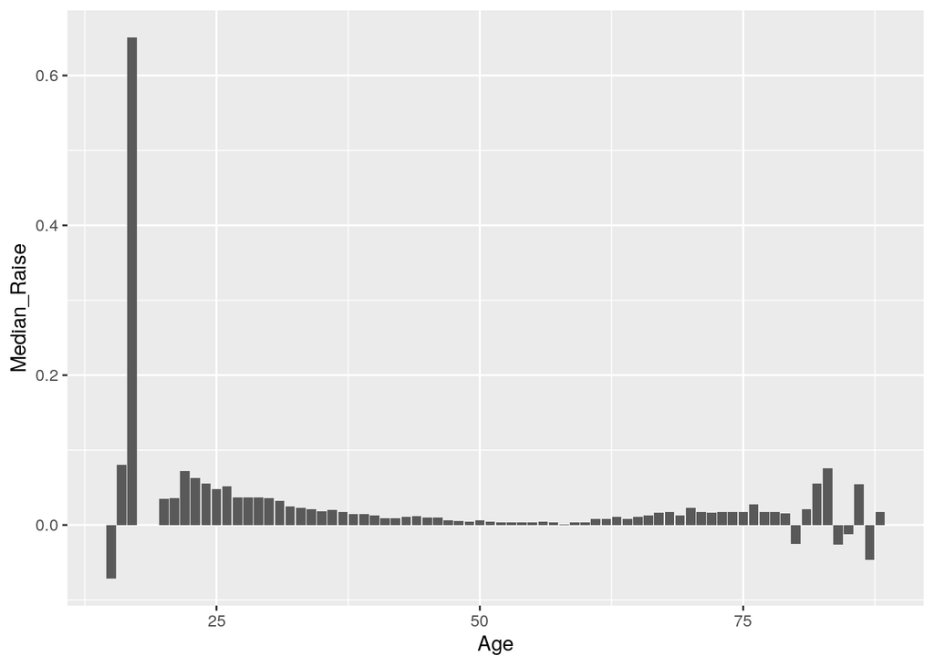

```r
agedata <- aggregate(Age, by = c(list(paydata$fullName)),
                                              min)
colnames(agedata) <- c('Name', "Age")
raisesbyAge <- merge(raises, agedata, by.x = "Name", by.y = "Name")

raisesbyAge <- aggregate(raisesbyAge$value, by = c(list(raisesbyAge$Age)), median)
raisesbyAge <- raisesbyAge[2:nrow(raisesbyAge), ]
colnames(raisesbyAge) <- c("Age", "Median_Raise")

ggplot(raisesbyAge, aes(x = Age, y = Median_Raise)) +
  geom_col()
```

Here I made a plot of the median raise for each age group. It appears that raises are larger for younger people.

```r
cor.test(raisesbyAge$Age, raisesbyAge$Median_Raise)
```

```
##
##  Pearson's product-moment correlation
##
## data:  raisesbyAge$Age and raisesbyAge$Median_Raise
## t = -2.21, df = 72, p-value = 0.03028
## alternative hypothesis: true correlation is not equal to 0
## 95 percent confidence interval:
##  -0.45437614 -0.02498617
## sample estimates:
##        cor
## -0.2520459
```

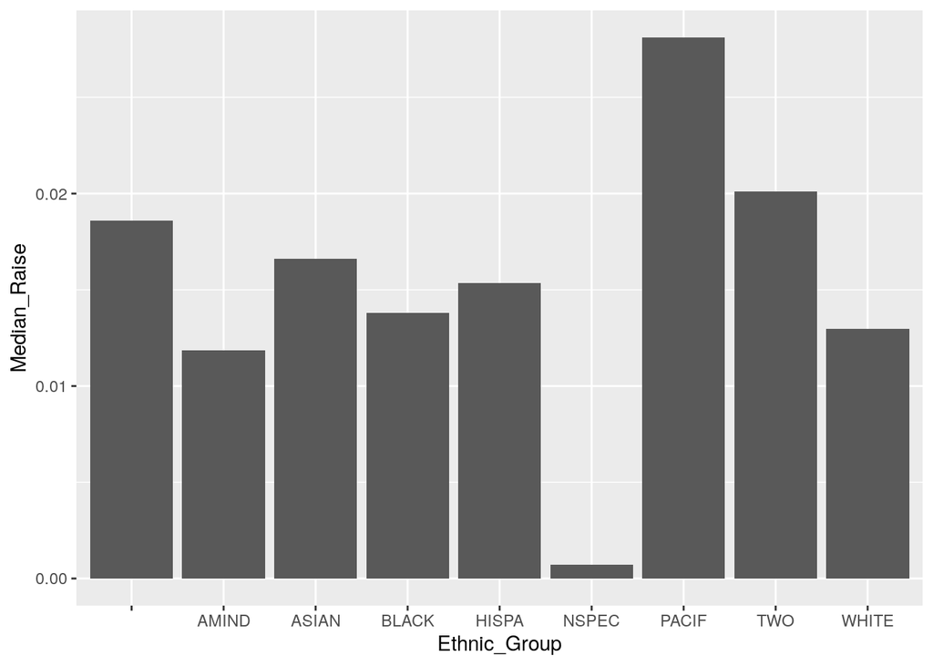

```r
egdata <- aggregate(`Bi-Weekly Comp Rate`, by = c(list(paydata$fullName), list(`Ethnic Grp`)), median)
colnames(egdata) <- c('Name', "Ethnic_Group", "Payment")
raisesbyEG <- merge(raises, egdata, by.x = "Name", by.y = "Name")
raisesbyEG <- aggregate(raisesbyEG$value, by = c(list(raisesbyEG$Ethnic_Group)), median)
colnames(raisesbyEG) <- c("Ethnic_Group", "Median_Raise")

ggplot(raisesbyEG, aes(x = Ethnic_Group, y = Median_Raise)) +
  geom_col()
```

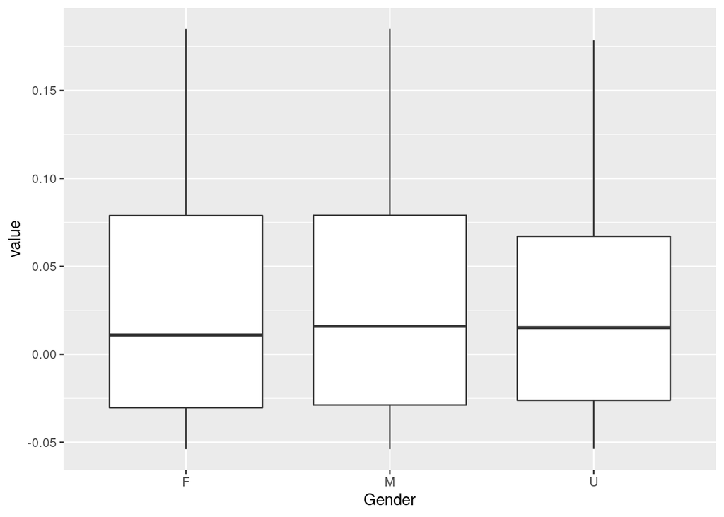

```r
genderdata <- aggregate(`Bi-Weekly Comp Rate`, by = c(list(paydata$fullName), list(Sex)), median)
colnames(genderdata) <- c('Name', "Gender", "Payment")
raisesbyGender <- merge(raises, genderdata, by.x = "Name", by.y = "Name")

ggplot(raisesbyGender, aes(x=Gender, y=value)) +
  geom_boxplot() +
  scale_y_continuous(limits = quantile(raisesbyGender$value, c(0.1, 0.9)))
```

Here I made a boxplot of the raise percentage by gender. By looking at this, it appears that there isn’t any difference in the size of the raise based on a person’s gender.

```r
summary(aov(raisesbyGender$value ~ raisesbyGender$Gender))
```

```
##                           Df  Sum Sq Mean Sq F value   Pr(>F)
## raisesbyGender$Gender      2    1153   576.5   17.52 2.48e-08 ***
## Residuals             251173 8267938    32.9
## ---
## Signif. codes:  0 '***' 0.001 '**' 0.01 '*' 0.05 '.' 0.1 ' ' 1
```

```r
aggregate(raisesbyGender$value, by = c(list(raisesbyGender$Gender)), mean)
```

```
##   Group.1         x
## 1       F 0.1913820
## 2       M 0.2184887
## 3       U 1.5643730
```

I tried to confirm this with an anova test, and we see that since our p-value is low, we can actually assume that there is a different mean raise percentage for different genders. I also calculated the sample mean for each gender group, and I found that the U category had a much higher mean. To compare only male and females, I decided to exclude the U category and do the test again.

```r
raisesbyGender <- subset(raisesbyGender,
                         raisesbyGender$Gender != "U")
summary(aov(raisesbyGender$value ~ raisesbyGender$Gender))
```

```
##                           Df  Sum Sq Mean Sq F value Pr(>F)
## raisesbyGender$Gender      1      46   45.95     1.4  0.237
## Residuals             250574 8225622   32.83
```

When I did the test with just male vs female, I got a high p-value, so I concluded that there is no difference between the amount of raises that men get compared to women.